# BOMBAS DE CALOR GEOTÉRMICAS

ANA ELIZABETH GALLEGOS SANTIAGO

08/032021

Naturaleza: la energía que utilizan las bombas de calor geotérmica, como su nombre lo dice esla energía geotérmica que no es más que el calor interno de la Tierra. Este calor interno calienta las capas de agua más profundas: al ascender, el agua caliente o el vapor producen manifestaciones, como son los géiseres o las fuentes termales. a energía geotérmica ha crecido en los últimos años impulsada por diversos factores como el crecimiento económico, el precio de los combustibles fósiles y las grandes emisiones de gases de efecto invernadero a la atmosfera.

Valor de uso: Una de las formas para extraer la energía geotérmica es la bomba de calor geotérmica vertical, que se instala a unos 150 o 200 pies bajo la superficie. A través de los tubos instalados en estos surcos excavados bajo tierra, circula agua (con anticongelante añadido) que eleva el calor para templar el fluido refrigerante.

Valor de cambio: Las nuevas tecnologías parecen estar aumentando la producción geotérmica, en algunas regiones se han tenido avances significativos en la producción utilizando ciclos binarios. Estas tecnologías permiten utilizar recursos geotérmicos de menor temperatura.

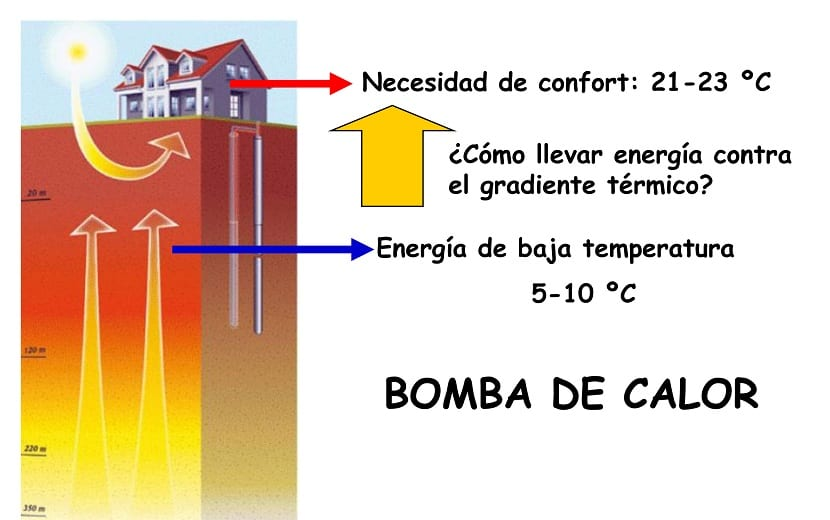

## Bibliografía

1. https://www.caloryfrio.com/energias-renovables/geotermia/bomba-de-calor-geotermica-funcionamiento-instalacion.html